# Восстановление золота из руды

Подготовьте прототип модели машинного обучения для «Цифры». Компания разрабатывает решения для эффективной работы промышленных предприятий.

Модель должна предсказать коэффициент восстановления золота из золотосодержащей руды. Используйте данные с параметрами добычи и очистки.

Модель поможет оптимизировать производство, чтобы не запускать предприятие с убыточными характеристиками.

Вам нужно:

1. Подготовить данные;
2. Провести исследовательский анализ данных;
3. Построить и обучить модель.

Чтобы выполнить проект, обращайтесь к библиотекам *pandas*, *matplotlib* и *sklearn.* Вам поможет их документация.

# Описание технологического процесса

Как золото получают из руды? Когда добытая руда проходит первичную обработку, получается дроблёная смесь. Её отправляют на флотацию (обогащение) и двухэтапную очистку.

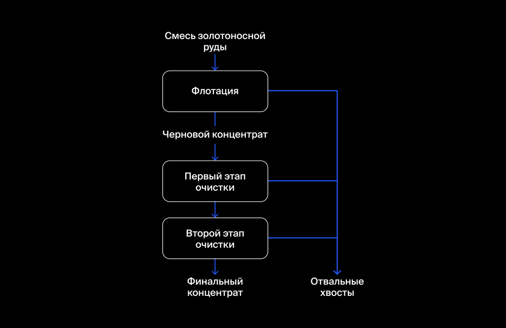

1. Флотация

Во флотационную установку подаётся смесь золотосодержащей руды. После обогащения получается черновой концентрат и «отвальные хвосты», то есть остатки продукта с низкой концентрацией ценных металлов.

На стабильность этого процесса влияет непостоянное и неоптимальное физико-химическое состояние флотационной пульпы (смеси твёрдых частиц и жидкости).

2. Очистка

Черновой концентрат проходит две очистки. На выходе получается финальный концентрат и новые отвальные хвосты.

# Описание данных

Технологический процесс

- Rougher feed — исходное сырье
- Rougher additions (или reagent additions) — флотационные реагенты: Xanthate, Sulphate, Depressant
- Xanthate — ксантогенат (промотер, или активатор флотации);
- Sulphate — сульфат (на данном производстве сульфид натрия);
- Depressant — депрессант (силикат натрия).
- Rougher process (англ. «грубый процесс») — флотация
- Rougher tails — отвальные хвосты
- Float banks — флотационная установка
- Cleaner process — очистка
- Rougher Au — черновой концентрат золота
- Final Au — финальный концентрат золота

Параметры этапов

- air amount — объём воздуха
- fluid levels — уровень жидкости
- feed size — размер гранул сырья
- feed rate — скорость подачи

# Наименование признаков

Наименование признаков должно быть такое:

[этап].[тип_параметра].[название_параметра]

Пример: rougher.input.feed_ag

Возможные значения для блока [этап]:

- rougher — флотация
- primary_cleaner — первичная очистка
- secondary_cleaner — вторичная очистка
- final — финальные характеристики

Возможные значения для блока [тип_параметра]:

- input — параметры сырья
- output — параметры продукта
- state — параметры, характеризующие текущее состояние этапа
- calculation — расчётные характеристики

# План работы

1. Подготовка данных
- Открыть файлы и изучить их.
- Проверить, что эффективность обогащения рассчитана правильно. Вычислить её на обучающей выборке для признака rougher.output.recovery. Найти MAE между расчётами и значением признака. Описать выводы.
- Проанализировать признаки, недоступные в тестовой выборке. Что это за параметры? К какому типу относятся?
- Провести предобработку данных.
2. Проанализировать данные
- Посмотреть, как меняется концентрация металлов (Au, Ag, Pb) на различных этапах: в сырье, в черновом концентрате, в концентрате после первой очистки и в финальном концентрате. Какие особенности имеют распределения? Описать выводы.
- Сравнить распределения размеров гранул исходного сырья на обучающей и тестовой выборках. Если распределения сильно отличаются друг от друга, оценка модели будет неправильной.
- Исследовать суммарную концентрацию металлов на разных стадиях: в сырье, в черновом концентрате, в концентрате после первой очистки и в финальном концентрате.
3. Построить модель
- Написать функцию для вычисления итоговой sMAPE.
- Обучить разные модели и оценить их качество кросс-валидацией. Выберать лучшую модель и проверить её на тестовой выборке. Описать выводы.

## Подготовка данных

```python
import pandas as pd
import matplotlib.pyplot as plt
import seaborn as sns
import numpy as np

from sklearn.preprocessing import StandardScaler

from sklearn.metrics import mean_absolute_error
from sklearn.metrics import mean_squared_error
from sklearn.model_selection import cross_val_score
from sklearn.metrics import make_scorer
from sklearn.model_selection import GridSearchCV, KFold

from catboost import CatBoostRegressor, Pool, cv

from sklearn.linear_model import LinearRegression
from sklearn.ensemble import RandomForestRegressor
from sklearn.dummy import DummyRegressor
```

```python
data_train = pd.read_csv('/datasets/gold_industry_train.csv')
data_test = pd.read_csv('/datasets/gold_industry_test.csv')
data_full = pd.read_csv('/datasets/gold_industry_full.csv')
```

### Data_train

Изучим все датасеты по порядку. Изучим размер, посмотрим на данные, проверим на налиие пропусков и дубликатов.

```python
data_train.info()
```

```
<class 'pandas.core.frame.DataFrame'>
RangeIndex: 14579 entries, 0 to 14578
Data columns (total 87 columns):
 #   Column                                              Non-Null Count  Dtype
---  ------                                              --------------  -----
 0   date                                                14579 non-null  object
 1   rougher.input.feed_au                               14579 non-null  float64
 2   rougher.input.feed_ag                               14579 non-null  float64
 3   rougher.input.feed_pb                               14507 non-null  float64
 4   rougher.input.feed_sol                              14502 non-null  float64
 5   rougher.input.feed_rate                             14572 non-null  float64
 6   rougher.input.feed_size                             14478 non-null  float64
 7   rougher.input.floatbank10_sulfate                   14548 non-null  float64
 8   rougher.input.floatbank10_xanthate                  14572 non-null  float64
 9   rougher.state.floatbank10_a_air                     14579 non-null  float64
```

[output cut: 79 more lines]

```python
data_train.head()
```

|  | date | rougher.input.feed_au | rougher.input.feed_ag | rougher.input.feed_pb | rougher.input.feed_sol | rougher.input.feed_rate | rougher.input.feed_size | rougher.input.floatbank10_sulfate | rougher.input.floatbank10_xanthate | rougher.state.floatbank10_a_air | ... | secondary_cleaner.output.tail_sol | final.output.concentrate_au | final.output.concentrate_ag | final.output.concentrate_pb | final.output.concentrate_sol | final.output.recovery | final.output.tail_au | final.output.tail_ag | final.output.tail_pb | final.output.tail_sol |
| --- | --- | --- | --- | --- | --- | --- | --- | --- | --- | --- | --- | --- | --- | --- | --- | --- | --- | --- | --- | --- | --- |
| 0 | 2016-01-15 00:00:00 | 6.486150 | 6.100378 | 2.284912 | 36.808594 | 523.546326 | 55.486599 | 11.986616 | 6.007990 | 999.706909 | ... | 8.764648 | 42.192020 | 6.055403 | 9.889648 | 5.507324 | 70.541216 | 2.143149 | 10.411962 | 0.895447 | 16.904297 |
| 1 | 2016-01-15 01:00:00 | 6.478583 | 6.161113 | 2.266033 | 35.753385 | 525.290581 | 57.278666 | 11.971193 | 6.005766 | 1000.286398 | ... | 9.001494 | 42.701629 | 6.029369 | 9.968944 | 5.257781 | 69.266198 | 2.224930 | 10.462676 | 0.927452 | 16.634514 |
| 2 | 2016-01-15 02:00:00 | 6.362222 | 6.116455 | 2.159622 | 35.971630 | 530.026610 | 57.510649 | 11.920603 | 6.197377 | 999.719565 | ... | 8.842896 | 42.657501 | 6.055926 | 10.213995 | 5.383759 | 68.116445 | 2.257889 | 10.507046 | 0.953716 | 16.208849 |
| 3 | 2016-01-15 03:00:00 | 6.118189 | 6.043309 | 2.037807 | 36.862241 | 542.590390 | 57.792734 | 11.630094 | 6.203177 | 999.814770 | ... | 9.122857 | 42.689819 | 6.047977 | 9.977019 | 4.858634 | 68.347543 | 2.146849 | 10.422762 | 0.883763 | 16.532835 |
| 4 | 2016-01-15 04:00:00 | 5.663707 | 6.060915 | 1.786875 | 34.347666 | 540.531893 | 56.047189 | 10.957755 | 6.198826 | 999.678690 | ... | 8.871028 | 42.774141 | 6.148599 | 10.142511 | 4.939416 | 66.927016 | 2.055292 | 10.360302 | 0.792826 | 16.525686 |

5 rows × 87 columns

```python
data_train.duplicated().sum()
```

```
0
```

```python
data_train.isna().sum().sort_values(ascending= False)
```

```
secondary_cleaner.output.tail_sol           920
rougher.state.floatbank10_e_air             429
rougher.input.floatbank11_xanthate          407
primary_cleaner.output.concentrate_sol      265
final.output.concentrate_sol                192
                                           ...
primary_cleaner.state.floatbank8_c_air        0
primary_cleaner.state.floatbank8_c_level      0
primary_cleaner.state.floatbank8_d_level      0
primary_cleaner.output.concentrate_au         0
primary_cleaner.state.floatbank8_b_level      0
Length: 87, dtype: int64
```

В датасете data_train 14579 строк и 87 стобцов. Нет дубликатов, есть пропущенные значения.

### Data_test

```python
data_test.info()
```

```
<class 'pandas.core.frame.DataFrame'>
RangeIndex: 4860 entries, 0 to 4859
Data columns (total 53 columns):
 #   Column                                      Non-Null Count  Dtype
---  ------                                      --------------  -----
 0   date                                        4860 non-null   object
 1   rougher.input.feed_au                       4860 non-null   float64
 2   rougher.input.feed_ag                       4860 non-null   float64
 3   rougher.input.feed_pb                       4832 non-null   float64
 4   rougher.input.feed_sol                      4838 non-null   float64
 5   rougher.input.feed_rate                     4856 non-null   float64
 6   rougher.input.feed_size                     4816 non-null   float64
 7   rougher.input.floatbank10_sulfate           4857 non-null   float64
 8   rougher.input.floatbank10_xanthate          4859 non-null   float64
 9   rougher.state.floatbank10_a_air             4859 non-null   float64
```

[output cut: 45 more lines]

```python
data_test.head()
```

|  | date | rougher.input.feed_au | rougher.input.feed_ag | rougher.input.feed_pb | rougher.input.feed_sol | rougher.input.feed_rate | rougher.input.feed_size | rougher.input.floatbank10_sulfate | rougher.input.floatbank10_xanthate | rougher.state.floatbank10_a_air | ... | secondary_cleaner.state.floatbank4_a_air | secondary_cleaner.state.floatbank4_a_level | secondary_cleaner.state.floatbank4_b_air | secondary_cleaner.state.floatbank4_b_level | secondary_cleaner.state.floatbank5_a_air | secondary_cleaner.state.floatbank5_a_level | secondary_cleaner.state.floatbank5_b_air | secondary_cleaner.state.floatbank5_b_level | secondary_cleaner.state.floatbank6_a_air | secondary_cleaner.state.floatbank6_a_level |
| --- | --- | --- | --- | --- | --- | --- | --- | --- | --- | --- | --- | --- | --- | --- | --- | --- | --- | --- | --- | --- | --- |
| 0 | 2017-12-09 14:59:59 | 4.365491 | 6.158718 | 3.875727 | 39.135119 | 555.820208 | 94.544358 | 6.146982 | 9.308612 | 1196.238112 | ... | 23.018622 | -500.492702 | 20.020205 | -500.220296 | 17.963512 | -499.939490 | 12.990306 | -500.080993 | 19.990336 | -499.191575 |
| 1 | 2017-12-09 15:59:59 | 4.362781 | 6.048130 | 3.902537 | 39.713906 | 544.731687 | 123.742430 | 6.210119 | 9.297709 | 1201.904177 | ... | 23.024963 | -501.153409 | 20.054122 | -500.314711 | 17.979515 | -499.272871 | 12.992404 | -499.976268 | 20.013986 | -500.625471 |
| 2 | 2017-12-09 16:59:59 | 5.081681 | 6.082745 | 4.564078 | 37.208683 | 558.155110 | 82.610855 | 7.363824 | 9.003562 | 1200.826926 | ... | 22.993827 | -501.559663 | 20.029144 | -500.000662 | 18.012723 | -500.024764 | 13.016445 | -500.058432 | 19.973767 | -501.394155 |
| 3 | 2017-12-09 17:59:59 | 5.145949 | 6.084374 | 4.768124 | 36.808874 | 539.713765 | 77.984784 | 6.927072 | 8.955597 | 1199.292489 | ... | 23.032807 | -501.287889 | 19.977466 | -500.159903 | 17.980463 | -500.504602 | 12.949071 | -500.009937 | 20.010332 | -508.337973 |
| 4 | 2017-12-09 18:59:59 | 5.735249 | 6.165220 | 4.512346 | 37.810642 | 558.713584 | 86.434874 | 7.823471 | 7.490356 | 1198.005449 | ... | 23.001911 | -499.947838 | 20.023735 | -499.713680 | 17.990955 | -500.334769 | 13.007523 | -499.968459 | 19.995999 | -499.788805 |

5 rows × 53 columns

```python
data_test.duplicated().sum()
```

```
0
```

```python
data_test.isna().sum().sort_values(ascending= False)
```

```
secondary_cleaner.state.floatbank2_a_air      126
rougher.input.floatbank11_xanthate             46
rougher.input.feed_size                        44
primary_cleaner.input.xanthate                 43
rougher.input.feed_pb                          28
rougher.input.feed_sol                         22
primary_cleaner.input.depressant                9
rougher.input.floatbank11_sulfate               8
rougher.state.floatbank10_e_air                 7
rougher.input.feed_rate                         4
rougher.input.floatbank10_sulfate               3
primary_cleaner.state.floatbank8_d_air          2
primary_cleaner.state.floatbank8_c_air          2
primary_cleaner.state.floatbank8_d_level        1
secondary_cleaner.state.floatbank3_a_level      1
secondary_cleaner.state.floatbank2_a_level      1
secondary_cleaner.state.floatbank2_b_air        1
secondary_cleaner.state.floatbank2_b_level      1
secondary_cleaner.state.floatbank3_a_air        1
secondary_cleaner.state.floatbank4_a_air        1
secondary_cleaner.state.floatbank3_b_air        1
secondary_cleaner.state.floatbank3_b_level      1
secondary_cleaner.state.floatbank4_a_level      1
secondary_cleaner.state.floatbank4_b_air        1
secondary_cleaner.state.floatbank4_b_level      1
secondary_cleaner.state.floatbank5_a_air        1
secondary_cleaner.state.floatbank5_a_level      1
secondary_cleaner.state.floatbank5_b_air        1
secondary_cleaner.state.floatbank5_b_level      1
secondary_cleaner.state.floatbank6_a_air        1
primary_cleaner.state.floatbank8_c_level        1
secondary_cleaner.state.floatbank6_a_level      1
primary_cleaner.state.floatbank8_b_level        1
rougher.state.floatbank10_c_air                 1
primary_cleaner.state.floatbank8_a_level        1
primary_cleaner.state.floatbank8_a_air          1
rougher.input.floatbank10_xanthate              1
primary_cleaner.input.sulfate                   1
rougher.state.floatbank10_a_air                 1
rougher.state.floatbank10_a_level               1
rougher.state.floatbank10_b_air                 1
primary_cleaner.state.floatbank8_b_air          1
rougher.state.floatbank10_b_level               1
rougher.state.floatbank10_c_level               1
rougher.input.feed_ag                           0
rougher.state.floatbank10_d_level               0
rougher.state.floatbank10_d_air                 0
rougher.state.floatbank10_e_level               0
rougher.state.floatbank10_f_air                 0
rougher.state.floatbank10_f_level               0
primary_cleaner.input.feed_size                 0
rougher.input.feed_au                           0
date                                            0
dtype: int64
```

### Data_full

```python
data_full.info()
```

```
<class 'pandas.core.frame.DataFrame'>
RangeIndex: 19439 entries, 0 to 19438
Data columns (total 87 columns):
 #   Column                                              Non-Null Count  Dtype
---  ------                                              --------------  -----
 0   date                                                19439 non-null  object
 1   rougher.input.feed_au                               19439 non-null  float64
 2   rougher.input.feed_ag                               19439 non-null  float64
 3   rougher.input.feed_pb                               19339 non-null  float64
 4   rougher.input.feed_sol                              19340 non-null  float64
 5   rougher.input.feed_rate                             19428 non-null  float64
 6   rougher.input.feed_size                             19294 non-null  float64
 7   rougher.input.floatbank10_sulfate                   19405 non-null  float64
 8   rougher.input.floatbank10_xanthate                  19431 non-null  float64
 9   rougher.state.floatbank10_a_air                     19438 non-null  float64
```

[output cut: 79 more lines]

```python
data_full.head()
```

|  | date | rougher.input.feed_au | rougher.input.feed_ag | rougher.input.feed_pb | rougher.input.feed_sol | rougher.input.feed_rate | rougher.input.feed_size | rougher.input.floatbank10_sulfate | rougher.input.floatbank10_xanthate | rougher.state.floatbank10_a_air | ... | secondary_cleaner.output.tail_sol | final.output.concentrate_au | final.output.concentrate_ag | final.output.concentrate_pb | final.output.concentrate_sol | final.output.recovery | final.output.tail_au | final.output.tail_ag | final.output.tail_pb | final.output.tail_sol |
| --- | --- | --- | --- | --- | --- | --- | --- | --- | --- | --- | --- | --- | --- | --- | --- | --- | --- | --- | --- | --- | --- |
| 0 | 2016-01-15 00:00:00 | 6.486150 | 6.100378 | 2.284912 | 36.808594 | 523.546326 | 55.486599 | 11.986616 | 6.007990 | 999.706909 | ... | 8.764648 | 42.192020 | 6.055403 | 9.889648 | 5.507324 | 70.541216 | 2.143149 | 10.411962 | 0.895447 | 16.904297 |
| 1 | 2016-01-15 01:00:00 | 6.478583 | 6.161113 | 2.266033 | 35.753385 | 525.290581 | 57.278666 | 11.971193 | 6.005766 | 1000.286398 | ... | 9.001494 | 42.701629 | 6.029369 | 9.968944 | 5.257781 | 69.266198 | 2.224930 | 10.462676 | 0.927452 | 16.634514 |
| 2 | 2016-01-15 02:00:00 | 6.362222 | 6.116455 | 2.159622 | 35.971630 | 530.026610 | 57.510649 | 11.920603 | 6.197377 | 999.719565 | ... | 8.842896 | 42.657501 | 6.055926 | 10.213995 | 5.383759 | 68.116445 | 2.257889 | 10.507046 | 0.953716 | 16.208849 |
| 3 | 2016-01-15 03:00:00 | 6.118189 | 6.043309 | 2.037807 | 36.862241 | 542.590390 | 57.792734 | 11.630094 | 6.203177 | 999.814770 | ... | 9.122857 | 42.689819 | 6.047977 | 9.977019 | 4.858634 | 68.347543 | 2.146849 | 10.422762 | 0.883763 | 16.532835 |
| 4 | 2016-01-15 04:00:00 | 5.663707 | 6.060915 | 1.786875 | 34.347666 | 540.531893 | 56.047189 | 10.957755 | 6.198826 | 999.678690 | ... | 8.871028 | 42.774141 | 6.148599 | 10.142511 | 4.939416 | 66.927016 | 2.055292 | 10.360302 | 0.792826 | 16.525686 |

5 rows × 87 columns

```python
data_full.duplicated().sum()
```

```
0
```

```python
data_full.isna().sum().sort_values(ascending= False)
```

```
secondary_cleaner.output.tail_sol           1748
rougher.input.floatbank11_xanthate           453
rougher.state.floatbank10_e_air              436
primary_cleaner.output.concentrate_sol       370
secondary_cleaner.state.floatbank2_a_air     220
                                            ...
rougher.output.tail_sol                        0
primary_cleaner.input.feed_size                0
rougher.input.feed_au                          0
primary_cleaner.output.concentrate_au          0
date                                           0
Length: 87, dtype: int64
```

### Отличия столбцов data_train и data_test

```python
# Определим на сколько столбцов отличаются data_train и data_test
train_columns = pd.Series(data_train.columns)
test_columns = pd.Series(data_test.columns)

train_columns.count() - test_columns.count()
```

```
34
```

```python
# Выведем эти столбцы на экран

not_in_test_columns = train_columns[~train_columns.isin(test_columns)].dropna()

not_in_test_columns
```

```
23        rougher.calculation.sulfate_to_au_concentrate
24    rougher.calculation.floatbank10_sulfate_to_au_...
25    rougher.calculation.floatbank11_sulfate_to_au_...
26                      rougher.calculation.au_pb_ratio
27                        rougher.output.concentrate_au
28                        rougher.output.concentrate_ag
29                        rougher.output.concentrate_pb
30                       rougher.output.concentrate_sol
31                              rougher.output.recovery
32                               rougher.output.tail_au
33                               rougher.output.tail_ag
34                               rougher.output.tail_pb
35                              rougher.output.tail_sol
48                primary_cleaner.output.concentrate_au
49                primary_cleaner.output.concentrate_ag
```

[output cut: 20 more lines]

```python
# Проверим, что их количество совпадает, и мы нашли то, что нужно

len(not_in_test_columns)
```

```
34
```

По наименованиям столбцов видим, что в тестовых данных нет:

- финальной концентрации au, ag,pb, sol
- финальных выходных данных по хвостам
- выходных данных au, ag,pb, sol после флоации и первой очистки
- выходных данных по хвостам после флоации, первой и второй очистки
- расчетных показателей на уровне флоации: sulfate_to_au_concentrate  
  floatbank10_sulfate_to_au_feed  
  floatbank11_sulfate_to_au_feed  
  au_pb_ratio

Разница между столбцами в данных train и test, на мой взгляд, связана с тем, что мы должны смоделировать концентрацию золота на выходе. Мы берем начальные столбцы данных по сырью и дальше запускаем процесс на них, поэтому тестируемые данные не содержат концентраций металлов после флоации, первой и второй очистки. Тк это было бы подсматриванием результата.

Технологически процесс идет от сырого сырья и далее запускается обработка. Соответственно тестовые данные не могут содержать столбцы данных, которые повяляются позже.

### Проверим, что эффективность обогащения рассчитана правильно

Вычислим её на обучающей выборке для признака rougher.output.recovery. Найдем MAE между нашими расчётами и значением признака.

Эффективность обогащения рассчитывается по формуле.

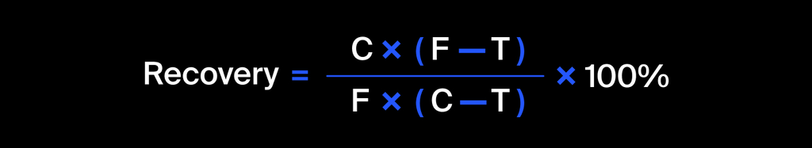

где:

- C — доля золота в концентрате после флотации/очистки;
- F — доля золота в сырье/концентрате до флотации/очистки;
- T — доля золота в отвальных хвостах после флотации/очистки.

```python
C = data_train['rougher.output.concentrate_au']
F = data_train['rougher.input.feed_au']
T = data_train['rougher.output.tail_au']

try:
   recovery = C * 100 * (F - T)/(F*C - F*T)
except:
    print('Есть деление на ноль')

recovery
```

```
0        87.107763
1        86.843261
2        86.842308
3        87.226430
4        86.688794
           ...
14574    87.684717
14575    90.677361
14576    89.574376
14577    87.724007
14578    88.890579
Length: 14579, dtype: float64
```

Проверим данные на адекватность. Посмотрим, где полученные данные меньше 0 и больше 100.

```python
(recovery<0).sum()
```

```
0
```

```python
(recovery>100).sum()
```

```
0
```

```python
(recovery==100).sum()
```

```
3
```

Этих данных не так много. Теперь посчитаем MAE.

```python
mean_absolute_error(recovery, data_train['rougher.output.recovery'])
```

```
1.2612815883515744e-14
```

Ошибка достачно маленькая, чтобы сказать, что эффективность обогащения рассчитана правильно.

### Предобработка данных

У нас были пропущенные значения в каждом из датасетов.

Есть два способа избавиться от пропущенных данных - заполнить их чем-то или удалить.

Заполнить можно, например, в нашем случае данными предыдущей строки - тк данные идут по времени, и по времени же не сильно отличаются друг от друга рядом стоящие строки.

Посчитаем, количество пропущенных значений в полных данных в % соотношении.

```python
# Самое большое число пропущенных значений

data_full.isna().sum().sort_values(ascending= False)[0]
```

```
1748
```

```python
# Найдем какой это % от общий данных

round(data_full.isna().sum().sort_values(ascending= False)[0] / data_full.shape[0] *100,2)
```

```
8.99
```

Число пропущенных значений меньше 10%. Можем удалить эти данные без серьезных потерь в data_full и аналогично удалить в других датафреймах. Но тогда мы столкнемся с проблемой, что тк данные в data_test содержат не все столбцы, их останется больше.

Это можно решить через запомнимание разбиения данных по датам, но можно сделать проще и заполнить пропущенные данные похожими по времени - из предыдущей строки. Так и сделаем.

```python
df_full = data_full.ffill(axis=0)
df_train = data_train.ffill(axis=0)
df_test = data_test.ffill(axis=0)

print(df_full.shape)
print(df_train.shape)
print(df_test.shape)
```

```
(19439, 87)
(14579, 87)
(4860, 53)
```

```python
# Проверим пропуски после заполнения

print(df_full.isna().sum())
print(df_train.isna().sum())
print(df_test.isna().sum())
```

```
date                      0
rougher.input.feed_au     0
rougher.input.feed_ag     0
rougher.input.feed_pb     0
rougher.input.feed_sol    0
                         ..
final.output.recovery     0
final.output.tail_au      0
final.output.tail_ag      0
final.output.tail_pb      0
final.output.tail_sol     0
Length: 87, dtype: int64
date                      0
rougher.input.feed_au     0
rougher.input.feed_ag     0
rougher.input.feed_pb     0
rougher.input.feed_sol    0
                         ..
final.output.recovery     0
final.output.tail_au      0
final.output.tail_ag      0
final.output.tail_pb      0
final.output.tail_sol     0
Length: 87, dtype: int64
date                                          0
rougher.input.feed_au                         0
rougher.input.feed_ag                         0
rougher.input.feed_pb                         0
rougher.input.feed_sol                        0
rougher.input.feed_rate                       0
rougher.input.feed_size                       0
rougher.input.floatbank10_sulfate             0
rougher.input.floatbank10_xanthate            0
rougher.state.floatbank10_a_air               0
rougher.state.floatbank10_a_level             0
rougher.state.floatbank10_b_air               0
rougher.state.floatbank10_b_level             0
rougher.state.floatbank10_c_air               0
rougher.state.floatbank10_c_level             0
rougher.state.floatbank10_d_air               0
```

[output cut: 23 more lines]

```
secondary_cleaner.state.floatbank3_a_air      0
secondary_cleaner.state.floatbank3_a_level    0
secondary_cleaner.state.floatbank3_b_air      0
secondary_cleaner.state.floatbank3_b_level    0
secondary_cleaner.state.floatbank4_a_air      0
secondary_cleaner.state.floatbank4_a_level    0
secondary_cleaner.state.floatbank4_b_air      0
secondary_cleaner.state.floatbank4_b_level    0
secondary_cleaner.state.floatbank5_a_air      0
secondary_cleaner.state.floatbank5_a_level    0
secondary_cleaner.state.floatbank5_b_air      0
secondary_cleaner.state.floatbank5_b_level    0
secondary_cleaner.state.floatbank6_a_air      0
secondary_cleaner.state.floatbank6_a_level    0
dtype: int64
```

Пропусков нет.

### Вывод

Вычислили MAE между расчётами показателя по формуле и значением признака из данных data_train. Получили значение MAE = 1.2612815883515744e-14

- Сравнили число столбцов в data_train и data_test. В тестовых данных нет 34 столбцов с данными финальной концентрации au, ag,pb, sol и хвостов. Выходных данных au, ag,pb, sol и хвостов после флоации и первой очистки, расчетных показателей на уровне флоации: sulfate_to_au_concentrate  
  floatbank10_sulfate_to_au_feed  
  floatbank11_sulfate_to_au_feed  
  au_pb_ratio

Разница между столбцами в данных train и test, на мой взгляд, связана с тем, что мы должны смоделировать концентрацию золота на выходе. Мы берем начальные столбцы данных по сырью и дальше запускаем процесс на них, поэтому тестируемые данные не содержат концентраций металлов после флоации, первой и второй очистки. Тк это было бы подсматриванием результата.

Технологически процесс идет от сырого сырья и далее запускается обработка. Соответственно тестовые данные не могут содержать столбцы данных, которые повяляются позже.

## Анализ данных

### Как меняется концентрация металлов (Au, Ag, Pb) на различных этапах?

Построим графики распределения металлов на разных этапах - в сырье, в черновом концентрате, в концентрате после первой очистки и в финальном концентрате.

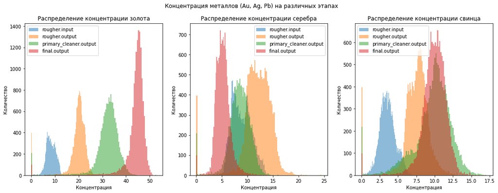

```python
fig, [ax0, ax1, ax2] = plt.subplots(1, 3, figsize = (18,6))
fig.suptitle('Концентрация металлов (Au, Ag, Pb) на различных этапах')


ax0.hist(df_train['rougher.input.feed_au'], bins=110, label = 'rougher.input', alpha=.5)
ax0.hist(df_train['rougher.output.concentrate_au'], bins=110, label = 'rougher.output', alpha=.5)
ax0.hist(df_train['primary_cleaner.output.concentrate_au'], bins=110, label = 'primary_cleaner.output', alpha=.5)
ax0.hist(df_train['final.output.concentrate_au'], bins=110, label = 'final.output', alpha=.5)

ax0.legend(prop={'size': 10})
ax0.set_title("Распределение концентрации золота")


ax1.hist(df_train['rougher.input.feed_ag'], bins=110, label = 'rougher.input', alpha=.5)
ax1.hist(df_train['rougher.output.concentrate_ag'], bins=110, label = 'rougher.output', alpha=.5)
ax1.hist(df_train['primary_cleaner.output.concentrate_ag'], bins=110, label = 'primary_cleaner.output', alpha=.5)
ax1.hist(df_train['final.output.concentrate_ag'], bins=110, label = 'final.output', alpha=.5)

ax1.legend(prop={'size': 10})
ax1.set_title("Распределение концентрации серебра")

ax2.hist(df_train['rougher.input.feed_pb'], bins=110, label = 'rougher.input', alpha=.5)
ax2.hist(df_train['rougher.output.concentrate_pb'], bins=110, label = 'rougher.output', alpha=.5)
ax2.hist(df_train['primary_cleaner.output.concentrate_pb'], bins=110, label = 'primary_cleaner.output', alpha=.5)
ax2.hist(df_train['final.output.concentrate_pb'], bins=110, label = 'final.output', alpha=.5)


ax2.legend(prop={'size': 10})
ax2.set_title("Распределение концентрации свинца")

ax0.set_xlabel("Концентрация")
ax0.set_ylabel("Количество")

ax1.set_xlabel("Концентрация")
ax1.set_ylabel("Количество")

ax2.set_xlabel("Концентрация")
ax2.set_ylabel("Количество")

plt.show()
```

- Концентрация золота растет после всех этапов очистки.
- Концентрация серебра значительно падает - возможно серебро попадает в хвосты.
- Концентрация свинца растет. Обогащение соединений свинца возможна из-за растворения части золота в свинце. Подробнее о процессе обогащения [тут](https://top-technologies.ru/ru/article/view?id=22441)
- Есть нулевые показатели концентрации у всех металлов на всех этапах очистки

```python
df_train_clean = df_train[df_train['rougher.output.concentrate_ag']>0.5]
df_full_clean = df_full[df_full['rougher.output.concentrate_ag']>0.5]

concentrate_array = ['primary_cleaner.output.concentrate_au', 'final.output.concentrate_au',
                     'rougher.output.concentrate_ag', 'primary_cleaner.output.concentrate_ag',
                     'final.output.concentrate_ag', 'rougher.output.concentrate_pb',
                     'primary_cleaner.output.concentrate_pb', 'final.output.concentrate_pb',
                     'rougher.input.feed_au', 'rougher.input.feed_ag', 'rougher.input.feed_pb',
                     'rougher.output.concentrate_au']


for x in concentrate_array:

    df_train_clean = df_train_clean[df_train_clean[x]>0.5]
    df_full_clean = df_full_clean[df_full_clean[x]>0.5]

df_train_clean.reset_index(drop= True , inplace= True)
df_full_clean.reset_index(drop= True , inplace= True)
```

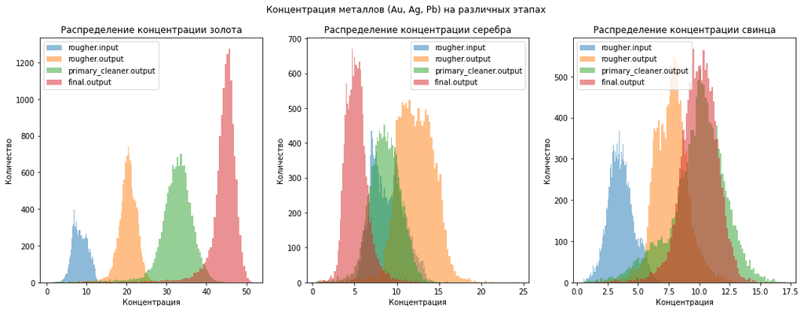

```python
fig, [ax0, ax1, ax2] = plt.subplots(1, 3, figsize = (18,6))
fig.suptitle('Концентрация металлов (Au, Ag, Pb) на различных этапах')


ax0.hist(df_train_clean['rougher.input.feed_au'], bins=110, label = 'rougher.input', alpha=.5)
ax0.hist(df_train_clean['rougher.output.concentrate_au'], bins=110, label = 'rougher.output', alpha=.5)
ax0.hist(df_train_clean['primary_cleaner.output.concentrate_au'], bins=110, label = 'primary_cleaner.output', alpha=.5)
ax0.hist(df_train_clean['final.output.concentrate_au'], bins=110, label = 'final.output', alpha=.5)

ax0.legend(prop={'size': 10})
ax0.set_title("Распределение концентрации золота")


ax1.hist(df_train_clean['rougher.input.feed_ag'], bins=110, label = 'rougher.input', alpha=.5)
ax1.hist(df_train_clean['rougher.output.concentrate_ag'], bins=110, label = 'rougher.output', alpha=.5)
ax1.hist(df_train_clean['primary_cleaner.output.concentrate_ag'], bins=110, label = 'primary_cleaner.output', alpha=.5)
ax1.hist(df_train_clean['final.output.concentrate_ag'], bins=110, label = 'final.output', alpha=.5)

ax1.legend(prop={'size': 10})
ax1.set_title("Распределение концентрации серебра")

ax2.hist(df_train_clean['rougher.input.feed_pb'], bins=110, label = 'rougher.input', alpha=.5)
ax2.hist(df_train_clean['rougher.output.concentrate_pb'], bins=110, label = 'rougher.output', alpha=.5)
ax2.hist(df_train_clean['primary_cleaner.output.concentrate_pb'], bins=110, label = 'primary_cleaner.output', alpha=.5)
ax2.hist(df_train_clean['final.output.concentrate_pb'], bins=110, label = 'final.output', alpha=.5)


ax2.legend(prop={'size': 10})
ax2.set_title("Распределение концентрации свинца")

ax0.set_xlabel("Концентрация")
ax0.set_ylabel("Количество")

ax1.set_xlabel("Концентрация")
ax1.set_ylabel("Количество")

ax2.set_xlabel("Концентрация")
ax2.set_ylabel("Количество")

plt.show()
```

### Сравните распределения размеров гранул исходного сырья на обучающей и тестовой выборках.

Распределение размера гранул совпадает на тестовой и обучающей выборках

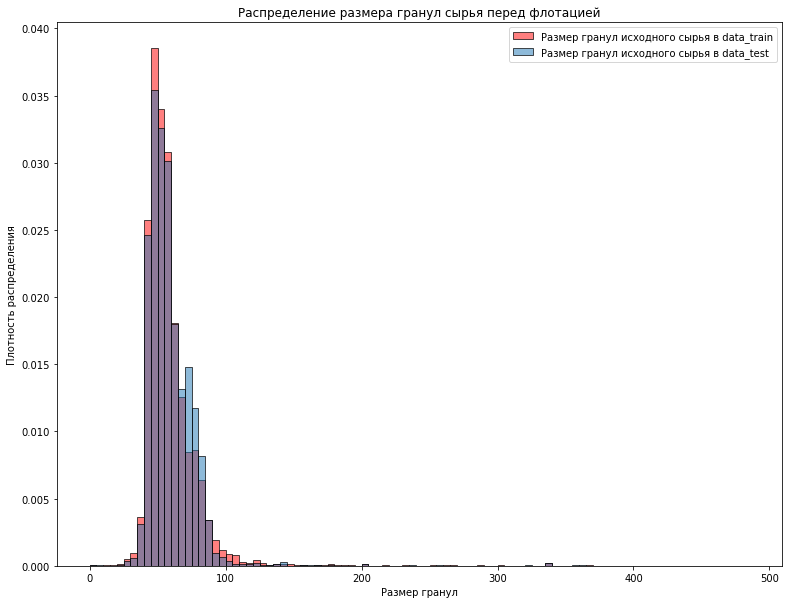

```python
plt.figure(figsize=[13,10])

sns.histplot(df_train_clean['rougher.input.feed_size'], stat='density', binwidth= 5, alpha=0.5, color = 'r')
sns.histplot(df_test['rougher.input.feed_size'], stat='density', binwidth= 5, alpha=0.5)

plt.xlabel("Размер гранул")
plt.ylabel("Плотность распределения")

plt.legend(labels=['Размер гранул исходного сырья в data_train', 'Размер гранул исходного сырья в data_test'])

plt.title("Распределение размера гранул сырья перед флотацией")
plt.show()
```

### Исследуйте суммарную концентрацию металлов на разных стадиях: в сырье, в черновом концентрате, в концентрате после первой очистки и в финальном концентрате.

Сложим данные о концентрации всех металлов на каждом этапе.

```python
df_rougher_input =  \
   df_train_clean[['rougher.input.feed_au','rougher.input.feed_ag', 'rougher.input.feed_pb','rougher.input.feed_sol']].sum(axis= 1)

df_rougher_output = \
   df_train_clean[['rougher.output.concentrate_au','rougher.output.concentrate_ag', \
             'rougher.output.concentrate_pb','rougher.output.concentrate_sol']].sum(axis= 1)

df_primary_cleaner_output = \
    df_train_clean[['primary_cleaner.output.concentrate_au', 'primary_cleaner.output.concentrate_ag', \
              'primary_cleaner.output.concentrate_pb', 'primary_cleaner.output.concentrate_sol']].sum(axis= 1)

df_final_output = \
    df_train_clean[['final.output.concentrate_au', 'final.output.concentrate_ag', 'final.output.concentrate_pb', \
             'final.output.concentrate_sol']].sum(axis= 1)
```

[figure not shown]

```python
# Построим графики распределения

plt.figure(figsize=[13,10])

plt.hist(df_rougher_input, bins=220, label = 'Общая концентрация металлов в исходном сырье', alpha=.5)
plt.hist(df_rougher_output, bins=220, label = 'Общая концентрация металлов после флоации', alpha=.5)
plt.hist(df_primary_cleaner_output, bins=220, label = 'Общая концентрация металлов после первой очистки', alpha=.5)
plt.hist(df_final_output, bins=220, label = 'Финальная общая концентрация металлов', alpha=.5)

plt.xlabel("Концентрация")
plt.ylabel("Количество результатов")

plt.legend(loc='upper left', fontsize='x-large')

plt.title("Распределение размера гранул сырья перед флотацией")
plt.show()
```

## Модель

### Напишите функцию для вычисления итоговой sMAPE

```python
def sMAPE(y_true,y_pred):
    error = np.mean(abs(y_true - y_pred)/((abs(y_true)+abs(y_pred))/2))*100
    return error
```

```python
def final_sMAPE(sMAPE_rougher,sMAPE_final):
    return (0.25*sMAPE_rougher + 0.75*sMAPE_final)
```

### Обучите разные модели и оцените их качество кросс-валидацией. Выберите лучшую модель и проверьте её на тестовой выборке. Опишите выводы.

Для адекватного обучения модели необходимо оставить в обучающей выборке только те столбцы, что есть в тестовой.

```python
# выбираем наименования столбцов, что есть в data_test

columns = df_test.columns

# оставим в features нужные столбцы из data_test, удалим столбец date как ненужный

features = df_train_clean[columns]
features = features.drop(['date'],axis=1)

target = df_train_clean[['rougher.output.recovery','final.output.recovery']]

target
```

|  | rougher.output.recovery | final.output.recovery |
| --- | --- | --- |
| 0 | 87.107763 | 70.541216 |
| 1 | 86.843261 | 69.266198 |
| 2 | 86.842308 | 68.116445 |
| 3 | 87.226430 | 68.347543 |
| 4 | 86.688794 | 66.927016 |
| ... | ... | ... |
| 13827 | 87.684717 | 64.054699 |
| 13828 | 90.677361 | 68.643324 |
| 13829 | 89.574376 | 73.755150 |
| 13830 | 87.724007 | 69.049291 |
| 13831 | 88.890579 | 67.002189 |

13832 rows × 2 columns

```python
scaler = StandardScaler()

columns_f = features.columns

scaler.fit(features[columns_f])

features[columns_f] = scaler.transform(features[columns_f])

features
```

|  | rougher.input.feed_au | rougher.input.feed_ag | rougher.input.feed_pb | rougher.input.feed_sol | rougher.input.feed_rate | rougher.input.feed_size | rougher.input.floatbank10_sulfate | rougher.input.floatbank10_xanthate | rougher.state.floatbank10_a_air | rougher.state.floatbank10_a_level | ... | secondary_cleaner.state.floatbank4_a_air | secondary_cleaner.state.floatbank4_a_level | secondary_cleaner.state.floatbank4_b_air | secondary_cleaner.state.floatbank4_b_level | secondary_cleaner.state.floatbank5_a_air | secondary_cleaner.state.floatbank5_a_level | secondary_cleaner.state.floatbank5_b_air | secondary_cleaner.state.floatbank5_b_level | secondary_cleaner.state.floatbank6_a_air | secondary_cleaner.state.floatbank6_a_level |
| --- | --- | --- | --- | --- | --- | --- | --- | --- | --- | --- | --- | --- | --- | --- | --- | --- | --- | --- | --- | --- | --- |
| 0 | -1.006099 | -1.460766 | -1.250755 | 0.043918 | 0.449251 | -0.155296 | -0.128045 | -0.016433 | -0.636536 | -0.243847 | ... | -0.904405 | -0.366930 | -0.564791 | -0.672555 | -1.022860 | -0.308063 | -0.745531 | -0.380346 | -0.885924 | -2.719039 |
| 1 | -1.010123 | -1.428908 | -1.268738 | -0.160997 | 0.465613 | -0.077875 | -0.132643 | -0.018404 | -0.632940 | -0.201741 | ... | -0.909167 | -0.428610 | -0.595628 | -0.621769 | -1.001675 | -0.360863 | -0.763788 | -0.383252 | -0.913747 | -2.555090 |
| 2 | -1.071993 | -1.452333 | -1.370093 | -0.118615 | 0.510040 | -0.067852 | -0.147724 | 0.151443 | -0.636458 | -0.201834 | ... | -0.904758 | -0.367603 | -0.603419 | -0.618796 | -0.995770 | -0.359704 | -0.758187 | -0.381564 | -0.908235 | -2.599502 |
| 3 | -1.201748 | -1.490701 | -1.486120 | 0.054335 | 0.627898 | -0.055666 | -0.234327 | 0.156584 | -0.635867 | -0.203161 | ... | -0.900589 | -0.333573 | -0.585510 | -0.619701 | -1.014519 | -0.333371 | -0.765218 | -0.374723 | -0.912438 | -2.560748 |
| 4 | -1.443401 | -1.481465 | -1.725130 | -0.433978 | 0.608588 | -0.131077 | -0.434755 | 0.152727 | -0.636711 | -0.198453 | ... | -0.902376 | -0.312735 | -0.595104 | -0.617603 | -1.022846 | -0.403925 | -0.781200 | -0.377341 | -0.914058 | -2.601379 |
| ... | ... | ... | ... | ... | ... | ... | ... | ... | ... | ... | ... | ... | ... | ... | ... | ... | ... | ... | ... | ... | ... |
| 13827 | -2.009239 | -1.606741 | 0.626251 | 0.174393 | 0.790229 | 1.130420 | -1.681400 | 2.640535 | 0.609187 | 0.850993 | ... | 0.843928 | -0.340516 | 1.072926 | -0.599419 | 0.483003 | -0.352405 | 0.200641 | -0.368760 | 0.179020 | 0.123873 |
| 13828 | -1.978080 | -1.594826 | 0.612933 | 0.157903 | 0.804955 | 1.070526 | -1.682981 | 2.636515 | 0.612311 | 0.850982 | ... | 0.844374 | -0.334696 | 1.063431 | -0.603679 | 0.484909 | -0.358617 | 0.202333 | -0.374784 | 0.174795 | 0.077001 |
| 13829 | -1.617719 | -1.465237 | 0.971064 | 0.152895 | 0.799554 | 1.150780 | -1.387198 | 2.776319 | 0.601686 | 0.842229 | ... | 0.844034 | -0.339927 | 1.067380 | -0.597888 | 0.483849 | -0.351335 | 0.201180 | -0.372103 | 0.179153 | 0.111803 |
| 13830 | -1.882109 | -1.449779 | 0.520947 | 0.390155 | 0.782131 | 2.610191 | -1.508253 | 2.906040 | 0.585076 | 0.856258 | ... | 0.830186 | -0.349027 | 1.073178 | -0.605561 | 0.482450 | -0.367257 | 0.192127 | -0.365292 | 0.171999 | 0.118703 |
| 13831 | -2.048831 | -1.528883 | 0.401898 | 0.678042 | 0.750716 | 2.729578 | -1.737993 | 2.901301 | 0.636565 | 0.859168 | ... | 0.840974 | -0.351048 | 1.055751 | -0.599643 | 0.486367 | -0.368846 | 0.205473 | -0.365795 | 0.176070 | 0.105791 |

13832 rows × 52 columns

Теперь рассмотрим разные модели

#### Линейная регрессия

```python
def my_custom_loss_func(target, prediction):

    target = np.array(target)
    prediction = np.array(prediction)

    smape_rougher = sMAPE(target[:,0],prediction[:,0])
    smape_final = sMAPE(target[:,1],prediction[:,1])

    return smape_final

my_scorer = make_scorer(my_custom_loss_func, greater_is_better=False)

# использую модель LinearRegression

model_LRS = LinearRegression()

scores = cross_val_score(model_LRS, features, target, cv=5, scoring=my_scorer)


print('Средняя оценка качества модели:', np.mean(abs(scores)))
```

```
Средняя оценка качества модели: 9.402839954646197
```

#### Случайный лес

```python
parametrs = { 'n_estimators': range (10, 50, 10),
              'max_depth': range (1,11, 1)}

model_RFG = RandomForestRegressor(random_state= 12345)
```

```python
grid = GridSearchCV(model_RFG, parametrs, cv=5, scoring=my_scorer)
grid.fit(features,target)
```

```
GridSearchCV(cv=5, estimator=RandomForestRegressor(random_state=12345),
             param_grid={'max_depth': range(1, 11),
                         'n_estimators': range(10, 50, 10)},
             scoring=make_scorer(my_custom_loss_func, greater_is_better=False))
```

```python
grid.best_params_
```

```
{'max_depth': 3, 'n_estimators': 30}
```

```python
abs(grid.best_score_)
```

```
8.996190315096953
```

### Оценка качества на тестовых данных

Тестовые данные не содержат целевые признаки 'rougher.output.recovery', 'final.output.recovery'.

Чтобы найти их возьмем тестовые данные, и в полном датафрейме по столбцу date найдем нужные столбцы.

```python
df_test
```

|  | date | rougher.input.feed_au | rougher.input.feed_ag | rougher.input.feed_pb | rougher.input.feed_sol | rougher.input.feed_rate | rougher.input.feed_size | rougher.input.floatbank10_sulfate | rougher.input.floatbank10_xanthate | rougher.state.floatbank10_a_air | ... | secondary_cleaner.state.floatbank4_a_air | secondary_cleaner.state.floatbank4_a_level | secondary_cleaner.state.floatbank4_b_air | secondary_cleaner.state.floatbank4_b_level | secondary_cleaner.state.floatbank5_a_air | secondary_cleaner.state.floatbank5_a_level | secondary_cleaner.state.floatbank5_b_air | secondary_cleaner.state.floatbank5_b_level | secondary_cleaner.state.floatbank6_a_air | secondary_cleaner.state.floatbank6_a_level |
| --- | --- | --- | --- | --- | --- | --- | --- | --- | --- | --- | --- | --- | --- | --- | --- | --- | --- | --- | --- | --- | --- |
| 0 | 2017-12-09 14:59:59 | 4.365491 | 6.158718 | 3.875727 | 39.135119 | 555.820208 | 94.544358 | 6.146982 | 9.308612 | 1196.238112 | ... | 23.018622 | -500.492702 | 20.020205 | -500.220296 | 17.963512 | -499.939490 | 12.990306 | -500.080993 | 19.990336 | -499.191575 |
| 1 | 2017-12-09 15:59:59 | 4.362781 | 6.048130 | 3.902537 | 39.713906 | 544.731687 | 123.742430 | 6.210119 | 9.297709 | 1201.904177 | ... | 23.024963 | -501.153409 | 20.054122 | -500.314711 | 17.979515 | -499.272871 | 12.992404 | -499.976268 | 20.013986 | -500.625471 |
| 2 | 2017-12-09 16:59:59 | 5.081681 | 6.082745 | 4.564078 | 37.208683 | 558.155110 | 82.610855 | 7.363824 | 9.003562 | 1200.826926 | ... | 22.993827 | -501.559663 | 20.029144 | -500.000662 | 18.012723 | -500.024764 | 13.016445 | -500.058432 | 19.973767 | -501.394155 |
| 3 | 2017-12-09 17:59:59 | 5.145949 | 6.084374 | 4.768124 | 36.808874 | 539.713765 | 77.984784 | 6.927072 | 8.955597 | 1199.292489 | ... | 23.032807 | -501.287889 | 19.977466 | -500.159903 | 17.980463 | -500.504602 | 12.949071 | -500.009937 | 20.010332 | -508.337973 |
| 4 | 2017-12-09 18:59:59 | 5.735249 | 6.165220 | 4.512346 | 37.810642 | 558.713584 | 86.434874 | 7.823471 | 7.490356 | 1198.005449 | ... | 23.001911 | -499.947838 | 20.023735 | -499.713680 | 17.990955 | -500.334769 | 13.007523 | -499.968459 | 19.995999 | -499.788805 |
| ... | ... | ... | ... | ... | ... | ... | ... | ... | ... | ... | ... | ... | ... | ... | ... | ... | ... | ... | ... | ... | ... |
| 4855 | 2018-08-18 06:59:59 | 6.620245 | 5.992592 | 2.589242 | 39.934641 | 578.654582 | 63.473450 | 14.688804 | 6.898599 | 999.688257 | ... | 14.003057 | -503.152258 | 12.016724 | -501.136446 | 10.041864 | -499.338844 | 8.007022 | -500.279583 | 14.001271 | -602.072365 |
| 4856 | 2018-08-18 07:59:59 | 6.741324 | 6.158617 | 2.647185 | 40.176307 | 571.622005 | 62.815291 | 14.892720 | 6.903204 | 1000.479783 | ... | 14.031220 | -503.471307 | 11.966426 | -500.656842 | 10.051620 | -498.318772 | 8.018091 | -499.696138 | 13.958937 | -599.213013 |
| 4857 | 2018-08-18 08:59:59 | 6.627458 | 6.015149 | 2.466127 | 39.841423 | 563.733146 | 61.287347 | 13.723692 | 6.700148 | 1000.014718 | ... | 13.996317 | -502.995300 | 11.980055 | -500.607751 | 9.964501 | -499.261719 | 8.065048 | -499.492395 | 13.997801 | -600.621416 |
| 4858 | 2018-08-18 09:59:59 | 6.702243 | 6.097592 | 2.278955 | 37.728375 | 549.812490 | 59.637037 | 13.746510 | 6.706417 | 999.635748 | ... | 13.983963 | -503.675714 | 11.928745 | -500.583183 | 9.970359 | -498.822343 | 8.016377 | -499.013145 | 14.000032 | -600.024741 |
| 4859 | 2018-08-18 10:59:59 | 6.633002 | 5.908793 | 2.440899 | 36.958540 | 573.076049 | 58.509262 | 13.707775 | 6.820245 | 1000.589156 | ... | 13.989632 | -503.195299 | 12.052233 | -500.928547 | 9.962574 | -502.986357 | 7.979219 | -500.146835 | 13.981614 | -598.070855 |

4860 rows × 53 columns

```python
target_test = df_full_clean[['date','rougher.output.recovery','final.output.recovery']]

target_test = df_test.merge(target_test,on=['date'],how='left')

target_test
```

|  | date | rougher.input.feed_au | rougher.input.feed_ag | rougher.input.feed_pb | rougher.input.feed_sol | rougher.input.feed_rate | rougher.input.feed_size | rougher.input.floatbank10_sulfate | rougher.input.floatbank10_xanthate | rougher.state.floatbank10_a_air | ... | secondary_cleaner.state.floatbank4_b_air | secondary_cleaner.state.floatbank4_b_level | secondary_cleaner.state.floatbank5_a_air | secondary_cleaner.state.floatbank5_a_level | secondary_cleaner.state.floatbank5_b_air | secondary_cleaner.state.floatbank5_b_level | secondary_cleaner.state.floatbank6_a_air | secondary_cleaner.state.floatbank6_a_level | rougher.output.recovery | final.output.recovery |
| --- | --- | --- | --- | --- | --- | --- | --- | --- | --- | --- | --- | --- | --- | --- | --- | --- | --- | --- | --- | --- | --- |
| 0 | 2017-12-09 14:59:59 | 4.365491 | 6.158718 | 3.875727 | 39.135119 | 555.820208 | 94.544358 | 6.146982 | 9.308612 | 1196.238112 | ... | 20.020205 | -500.220296 | 17.963512 | -499.939490 | 12.990306 | -500.080993 | 19.990336 | -499.191575 | 89.514960 | 70.281454 |
| 1 | 2017-12-09 15:59:59 | 4.362781 | 6.048130 | 3.902537 | 39.713906 | 544.731687 | 123.742430 | 6.210119 | 9.297709 | 1201.904177 | ... | 20.054122 | -500.314711 | 17.979515 | -499.272871 | 12.992404 | -499.976268 | 20.013986 | -500.625471 | 89.858126 | 65.523246 |
| 2 | 2017-12-09 16:59:59 | 5.081681 | 6.082745 | 4.564078 | 37.208683 | 558.155110 | 82.610855 | 7.363824 | 9.003562 | 1200.826926 | ... | 20.029144 | -500.000662 | 18.012723 | -500.024764 | 13.016445 | -500.058432 | 19.973767 | -501.394155 | 91.816623 | 74.817644 |
| 3 | 2017-12-09 17:59:59 | 5.145949 | 6.084374 | 4.768124 | 36.808874 | 539.713765 | 77.984784 | 6.927072 | 8.955597 | 1199.292489 | ... | 19.977466 | -500.159903 | 17.980463 | -500.504602 | 12.949071 | -500.009937 | 20.010332 | -508.337973 | 88.478959 | 63.082720 |
| 4 | 2017-12-09 18:59:59 | 5.735249 | 6.165220 | 4.512346 | 37.810642 | 558.713584 | 86.434874 | 7.823471 | 7.490356 | 1198.005449 | ... | 20.023735 | -499.713680 | 17.990955 | -500.334769 | 13.007523 | -499.968459 | 19.995999 | -499.788805 | 89.230316 | 74.463380 |
| ... | ... | ... | ... | ... | ... | ... | ... | ... | ... | ... | ... | ... | ... | ... | ... | ... | ... | ... | ... | ... | ... |
| 4855 | 2018-08-18 06:59:59 | 6.620245 | 5.992592 | 2.589242 | 39.934641 | 578.654582 | 63.473450 | 14.688804 | 6.898599 | 999.688257 | ... | 12.016724 | -501.136446 | 10.041864 | -499.338844 | 8.007022 | -500.279583 | 14.001271 | -602.072365 | 85.462226 | 68.786981 |
| 4856 | 2018-08-18 07:59:59 | 6.741324 | 6.158617 | 2.647185 | 40.176307 | 571.622005 | 62.815291 | 14.892720 | 6.903204 | 1000.479783 | ... | 11.966426 | -500.656842 | 10.051620 | -498.318772 | 8.018091 | -499.696138 | 13.958937 | -599.213013 | 85.443505 | 67.839536 |
| 4857 | 2018-08-18 08:59:59 | 6.627458 | 6.015149 | 2.466127 | 39.841423 | 563.733146 | 61.287347 | 13.723692 | 6.700148 | 1000.014718 | ... | 11.980055 | -500.607751 | 9.964501 | -499.261719 | 8.065048 | -499.492395 | 13.997801 | -600.621416 | 87.235441 | 70.847012 |
| 4858 | 2018-08-18 09:59:59 | 6.702243 | 6.097592 | 2.278955 | 37.728375 | 549.812490 | 59.637037 | 13.746510 | 6.706417 | 999.635748 | ... | 11.928745 | -500.583183 | 9.970359 | -498.822343 | 8.016377 | -499.013145 | 14.000032 | -600.024741 | 89.299981 | 72.659046 |
| 4859 | 2018-08-18 10:59:59 | 6.633002 | 5.908793 | 2.440899 | 36.958540 | 573.076049 | 58.509262 | 13.707775 | 6.820245 | 1000.589156 | ... | 12.052233 | -500.928547 | 9.962574 | -502.986357 | 7.979219 | -500.146835 | 13.981614 | -598.070855 | 87.650868 | 70.279619 |

4860 rows × 55 columns

Оставим два последних столбца. Это и будут целевые значения.

```python
target_test = target_test[['rougher.output.recovery','final.output.recovery']]

target_test
```

|  | rougher.output.recovery | final.output.recovery |
| --- | --- | --- |
| 0 | 89.514960 | 70.281454 |
| 1 | 89.858126 | 65.523246 |
| 2 | 91.816623 | 74.817644 |
| 3 | 88.478959 | 63.082720 |
| 4 | 89.230316 | 74.463380 |
| ... | ... | ... |
| 4855 | 85.462226 | 68.786981 |
| 4856 | 85.443505 | 67.839536 |
| 4857 | 87.235441 | 70.847012 |
| 4858 | 89.299981 | 72.659046 |
| 4859 | 87.650868 | 70.279619 |

4860 rows × 2 columns

```python
# переводим в массив для дальнейших вычислений

target_test = np.array(target_test)

target_test
```

```
array([[89.51495973, 70.28145415],
       [89.858126  , 65.52324622],
       [91.81662274, 74.8176442 ],
       ...,
       [87.23544052, 70.84701216],
       [89.29998128, 72.65904642],
       [87.65086771, 70.27961943]])
```

```python
# из тестовых данных убираем столбец date

features_test = df_test.drop(['date'],axis=1)

features_test
```

|  | rougher.input.feed_au | rougher.input.feed_ag | rougher.input.feed_pb | rougher.input.feed_sol | rougher.input.feed_rate | rougher.input.feed_size | rougher.input.floatbank10_sulfate | rougher.input.floatbank10_xanthate | rougher.state.floatbank10_a_air | rougher.state.floatbank10_a_level | ... | secondary_cleaner.state.floatbank4_a_air | secondary_cleaner.state.floatbank4_a_level | secondary_cleaner.state.floatbank4_b_air | secondary_cleaner.state.floatbank4_b_level | secondary_cleaner.state.floatbank5_a_air | secondary_cleaner.state.floatbank5_a_level | secondary_cleaner.state.floatbank5_b_air | secondary_cleaner.state.floatbank5_b_level | secondary_cleaner.state.floatbank6_a_air | secondary_cleaner.state.floatbank6_a_level |
| --- | --- | --- | --- | --- | --- | --- | --- | --- | --- | --- | --- | --- | --- | --- | --- | --- | --- | --- | --- | --- | --- |
| 0 | 4.365491 | 6.158718 | 3.875727 | 39.135119 | 555.820208 | 94.544358 | 6.146982 | 9.308612 | 1196.238112 | -299.862743 | ... | 23.018622 | -500.492702 | 20.020205 | -500.220296 | 17.963512 | -499.939490 | 12.990306 | -500.080993 | 19.990336 | -499.191575 |
| 1 | 4.362781 | 6.048130 | 3.902537 | 39.713906 | 544.731687 | 123.742430 | 6.210119 | 9.297709 | 1201.904177 | -299.907308 | ... | 23.024963 | -501.153409 | 20.054122 | -500.314711 | 17.979515 | -499.272871 | 12.992404 | -499.976268 | 20.013986 | -500.625471 |
| 2 | 5.081681 | 6.082745 | 4.564078 | 37.208683 | 558.155110 | 82.610855 | 7.363824 | 9.003562 | 1200.826926 | -300.124116 | ... | 22.993827 | -501.559663 | 20.029144 | -500.000662 | 18.012723 | -500.024764 | 13.016445 | -500.058432 | 19.973767 | -501.394155 |
| 3 | 5.145949 | 6.084374 | 4.768124 | 36.808874 | 539.713765 | 77.984784 | 6.927072 | 8.955597 | 1199.292489 | -299.778385 | ... | 23.032807 | -501.287889 | 19.977466 | -500.159903 | 17.980463 | -500.504602 | 12.949071 | -500.009937 | 20.010332 | -508.337973 |
| 4 | 5.735249 | 6.165220 | 4.512346 | 37.810642 | 558.713584 | 86.434874 | 7.823471 | 7.490356 | 1198.005449 | -300.283401 | ... | 23.001911 | -499.947838 | 20.023735 | -499.713680 | 17.990955 | -500.334769 | 13.007523 | -499.968459 | 19.995999 | -499.788805 |
| ... | ... | ... | ... | ... | ... | ... | ... | ... | ... | ... | ... | ... | ... | ... | ... | ... | ... | ... | ... | ... | ... |
| 4855 | 6.620245 | 5.992592 | 2.589242 | 39.934641 | 578.654582 | 63.473450 | 14.688804 | 6.898599 | 999.688257 | -399.217124 | ... | 14.003057 | -503.152258 | 12.016724 | -501.136446 | 10.041864 | -499.338844 | 8.007022 | -500.279583 | 14.001271 | -602.072365 |
| 4856 | 6.741324 | 6.158617 | 2.647185 | 40.176307 | 571.622005 | 62.815291 | 14.892720 | 6.903204 | 1000.479783 | -399.574748 | ... | 14.031220 | -503.471307 | 11.966426 | -500.656842 | 10.051620 | -498.318772 | 8.018091 | -499.696138 | 13.958937 | -599.213013 |
| 4857 | 6.627458 | 6.015149 | 2.466127 | 39.841423 | 563.733146 | 61.287347 | 13.723692 | 6.700148 | 1000.014718 | -400.320877 | ... | 13.996317 | -502.995300 | 11.980055 | -500.607751 | 9.964501 | -499.261719 | 8.065048 | -499.492395 | 13.997801 | -600.621416 |
| 4858 | 6.702243 | 6.097592 | 2.278955 | 37.728375 | 549.812490 | 59.637037 | 13.746510 | 6.706417 | 999.635748 | -399.484884 | ... | 13.983963 | -503.675714 | 11.928745 | -500.583183 | 9.970359 | -498.822343 | 8.016377 | -499.013145 | 14.000032 | -600.024741 |
| 4859 | 6.633002 | 5.908793 | 2.440899 | 36.958540 | 573.076049 | 58.509262 | 13.707775 | 6.820245 | 1000.589156 | -398.879586 | ... | 13.989632 | -503.195299 | 12.052233 | -500.928547 | 9.962574 | -502.986357 | 7.979219 | -500.146835 | 13.981614 | -598.070855 |

4860 rows × 52 columns

```python
# масштабируем данные features_test

columns_ft = features_test.columns

scaler.fit(features_test[columns_ft])

features_test[columns_ft] = scaler.transform(features_test[columns_ft])

features_test
```

|  | rougher.input.feed_au | rougher.input.feed_ag | rougher.input.feed_pb | rougher.input.feed_sol | rougher.input.feed_rate | rougher.input.feed_size | rougher.input.floatbank10_sulfate | rougher.input.floatbank10_xanthate | rougher.state.floatbank10_a_air | rougher.state.floatbank10_a_level | ... | secondary_cleaner.state.floatbank4_a_air | secondary_cleaner.state.floatbank4_a_level | secondary_cleaner.state.floatbank4_b_air | secondary_cleaner.state.floatbank4_b_level | secondary_cleaner.state.floatbank5_a_air | secondary_cleaner.state.floatbank5_a_level | secondary_cleaner.state.floatbank5_b_air | secondary_cleaner.state.floatbank5_b_level | secondary_cleaner.state.floatbank6_a_air | secondary_cleaner.state.floatbank6_a_level |
| --- | --- | --- | --- | --- | --- | --- | --- | --- | --- | --- | --- | --- | --- | --- | --- | --- | --- | --- | --- | --- | --- |
| 0 | -1.826086 | -1.219685 | 0.297869 | 0.417151 | 0.694110 | 1.814829 | -1.733943 | 3.075241 | 0.560012 | 0.751502 | ... | 0.534820 | -0.266158 | 0.903398 | -0.548305 | 0.239477 | -0.282919 | 0.008199 | -0.283065 | 0.169027 | 0.142270 |
| 1 | -1.827445 | -1.276153 | 0.323306 | 0.534054 | 0.576623 | 3.311361 | -1.715421 | 3.064786 | 0.596224 | 0.751013 | ... | 0.535893 | -0.281042 | 0.910282 | -0.549742 | 0.242273 | -0.262250 | 0.008578 | -0.280240 | 0.173289 | 0.105224 |
| 2 | -1.466803 | -1.258478 | 0.950977 | 0.028053 | 0.718849 | 1.203184 | -1.376969 | 2.782719 | 0.589339 | 0.748635 | ... | 0.530626 | -0.290193 | 0.905213 | -0.544962 | 0.248075 | -0.285563 | 0.012923 | -0.282456 | 0.166041 | 0.085364 |
| 3 | -1.434562 | -1.257646 | 1.144576 | -0.052700 | 0.523457 | 0.966077 | -1.505095 | 2.736724 | 0.579533 | 0.752428 | ... | 0.537219 | -0.284071 | 0.894723 | -0.547386 | 0.242439 | -0.300441 | 0.000745 | -0.281148 | 0.172631 | -0.094037 |
| 4 | -1.138935 | -1.216365 | 0.901893 | 0.149636 | 0.724766 | 1.399182 | -1.242127 | 1.331661 | 0.571307 | 0.746887 | ... | 0.531994 | -0.253884 | 0.904115 | -0.540594 | 0.244272 | -0.295175 | 0.011311 | -0.280030 | 0.170048 | 0.126840 |
| ... | ... | ... | ... | ... | ... | ... | ... | ... | ... | ... | ... | ... | ... | ... | ... | ... | ... | ... | ... | ... | ... |
| 4855 | -0.694968 | -1.304512 | -0.922747 | 0.578638 | 0.936047 | 0.222306 | 0.771893 | 0.764207 | -0.696151 | -0.338427 | ... | -0.990019 | -0.326069 | -0.721141 | -0.562248 | -1.144487 | -0.264296 | -0.892531 | -0.288421 | -0.910324 | -2.515766 |
| 4856 | -0.634228 | -1.219736 | -0.867771 | 0.627449 | 0.861535 | 0.188572 | 0.831714 | 0.768623 | -0.691092 | -0.342350 | ... | -0.985256 | -0.333256 | -0.731351 | -0.554949 | -1.142783 | -0.232667 | -0.890530 | -0.272685 | -0.917954 | -2.441892 |
| 4857 | -0.691350 | -1.292994 | -1.039558 | 0.559809 | 0.777950 | 0.110258 | 0.488767 | 0.573907 | -0.694065 | -0.350535 | ... | -0.991159 | -0.322533 | -0.728584 | -0.554202 | -1.158003 | -0.261904 | -0.882043 | -0.267190 | -0.910949 | -2.478279 |
| 4858 | -0.653833 | -1.250897 | -1.217147 | 0.133019 | 0.630456 | 0.025673 | 0.495461 | 0.579918 | -0.696487 | -0.341365 | ... | -0.993249 | -0.337861 | -0.738999 | -0.553828 | -1.156980 | -0.248281 | -0.890840 | -0.254264 | -0.910547 | -2.462863 |
| 4859 | -0.688568 | -1.347301 | -1.063495 | -0.022470 | 0.876941 | -0.032131 | 0.484098 | 0.689072 | -0.690393 | -0.334724 | ... | -0.992290 | -0.327039 | -0.713934 | -0.559084 | -1.158340 | -0.377390 | -0.897556 | -0.284840 | -0.913867 | -2.412383 |

4860 rows × 52 columns

Сделаем предсказания на тестовых данных с помощью обученных моделей. Получим значения sMAPE.

```python
# Случайный лес

prediction_RF = model_RF.predict(features_test)

smape_rougher = sMAPE(target_test[:,0],prediction_RF[:,0])
smape_final = sMAPE(target_test[:,1],prediction_RF[:,1])

smape_final
```

```
7.889238726003453
```

```python
# прокарка модели на адекватность

dummy_regr = DummyRegressor()
dummy_regr.fit(features, target)

prediction_DM = dummy_regr.predict(features_test)


smape_rougher = sMAPE(target_test[:,0],prediction_DM[:,0])
smape_final = sMAPE(target_test[:,1],prediction_DM[:,1])

smape_final
```

```
9.260051328540113
```

# Общий вывод

Подготовка даных:

Вычислили MAE между расчётами показателя по формуле и значением признака из данных data_train. Получили значение MAE = 1.2612815883515744e-14

- Сравнили число столбцов в data_train и data_test. В тестовых данных нет 34 столбцов с данными финальной концентрации au, ag,pb, sol и хвостов. Выходных данных au, ag,pb, sol и хвостов после флоации и первой очистки, расчетных показателей на уровне флоации: sulfate_to_au_concentrate  
  floatbank10_sulfate_to_au_feed  
  floatbank11_sulfate_to_au_feed  
  au_pb_ratio

Разница между столбцами в данных train и test, на мой взгляд, связана с тем, что мы должны смоделировать концентрацию золота на выходе. Мы берем начальные столбцы данных по сырью и дальше запускаем процесс на них, поэтому тестируемые данные не содержат концентраций металлов после флоации, первой и второй очистки. Тк это было бы подсматриванием результата.

Технологически процесс идет от сырого сырья и далее запускается обработка. Соответственно тестовые данные не могут содержать столбцы данных, которые повяляются позже.